# Google Case Study 2

# How Can a Wellness Technology Company Play It Smart?

## Background

Urška Sršen, cofounder and Chief Creative Officer of [Bellabeat](https://bellabeat.com/), believes that analyzing smart device fitness data could help unlock new growth opportunities for the company. You have been asked to focus on one of Bellabeat’s products and analyze smart device data to gain insight into how consumers are using their smart devices. The insights you discover will then help guide the marketing strategy for the company.

Sršen asks you to analyze smart device usage data in order to gain insight into how consumers use non-Bellabeat smart devices. She then wants you to select one Bellabeat product to apply these insights to in your presentation.

## Questions for analysis:

- What are some trends in smart device usage?
- How could these trends apply to Bellabeat customers?
- How could these trends help influence Bellabeat marketing strategy?

## Deliverables:

- Clear summary of the business task
- Description of all data sources used
- Documentation of any cleaning or manipulation of data
- Summary of your analysis
- Supporting visualizations and key findings
- Your top high-level content recommendations based on your analysis

## 1. Ask

**Business task**: Gain insights into how consumers use non-Bellabeat smart devices and how they can be applied to one of the company's products. The insight will be used for providing guidance on marketing strategy.

## 2. Prepare

**Data source**: [FitBit Fitness Tracker Data](https://www.kaggle.com/arashnic/fitbit) (CC0: Public Domain, dataset made available through Mobius) stored on Kaggle. The data set contains personal fitness trackers from 30 Fitbit users who have consented to the submission of personal tracker data, including minute-level output for physical activity, heart rate, and sleep monitoring. It includes information about daily activity, steps, and heart rate that can be used to explore users’ habits.

**Data information**: There are 18 files on Kaggle that can be divided into the following categories: Activity, calorie, Intensity, Steps, and Sleep. Some of which have daily, hourly and minute data.

Download data from Kaggle, then glimpse the file with SQL and RStudio. Note that “dailyActivity_merged” contains data of “dailyIntensities_merged”, “dailySteps_merged” and "dailyCalories_merged" from 2016-04-12 to 2016-05-12.

Bellabeat’s tracker Leaf tracks activity, sleep and stress; therefore, after glimping the data, I decided to use the following files for analysis: * dailyActivity_merged.csv - 33 distinct user ID, 31 days, 15 variables, * sleepDay_merged.csv - 24 distinct user ID, 5 variables: Id, SleepDay, TotalSleepRecords, TotalMinutesAsleep, TotalTimeInBed * hourlyIntensities_merged.csv - 33 distinct user ID, 4 variables: Id, ActivityHour, TotalIntensity, AverageIntensity * hourlySteps_merged.csv - 33 distinct user ID, 3 variables: Id, ActivityHour, TotalSteps

### 2-1. Load packages

Load the packages needed for data processing and analysis.

```r
library(tidyr)
library(tidyverse)
library(tibble)
library(dbplyr)
library(utils)
library(lubridate)
```

### 2-2. Import files

```r
daily_activity <- read_csv("/Users/Linda/Desktop/RStudio/Google Data/CaseStudy/dailyActivity_merged.csv")
daily_calories <- read_csv("/Users/Linda/Desktop/RStudio/Google Data/CaseStudy/dailyCalories_merged.csv")
daily_intensity <- read_csv("/Users/Linda/Desktop/RStudio/Google Data/CaseStudy/dailyIntensities_merged.csv")
hourly_intensity <- read_csv("/Users/Linda/Desktop/RStudio/Google Data/CaseStudy/hourlyIntensities_merged.csv")
daily_steps <- read_csv("/Users/Linda/Desktop/RStudio/Google Data/CaseStudy/dailySteps_merged.csv")
hourly_steps <- read_csv("/Users/Linda/Desktop/RStudio/Google Data/CaseStudy/hourlySteps_merged.csv")
sleep_day <- read_csv("/Users/Linda/Desktop/RStudio/Google Data/CaseStudy/sleepDay_merged.csv")
```

## 3. Process

At the process stage, I will do:

1. Check for duplicates & missing values (NA)
2. Formate data for consistency
3. Merge data:
   1. Create dataset, daily_all = “dailyActivity_merged” with “sleepDay_merged” and merge
   2. Create dataset, hourly_all = “hourlyIntensities_merged” with “hourlySteps_merged”

### 3-1. Check duplicates & missing values (NA)

Check if there're any duplicates in the data.

```r
# check duplicates
sum(duplicated(daily_activity))  # 0 duplicate
```

```
## [1] 0
```

```r
sum(duplicated(sleep_day))  # 3 duplicates
```

```
## [1] 3
```

```r
sum(duplicated(hourly_intensity))  # 0 duplicate
```

```
## [1] 0
```

```r
sum(duplicated(hourly_steps))  # 0 duplicate
```

```
## [1] 0
```

There are 3 duplicates in the sleep_day, so we want to remove them.

```r
# remove duplicates
sleep_day <- distinct(sleep_day)
sum(duplicated(sleep_day))  # 3 duplicates
```

```
## [1] 0
```

Next, we want to check for missing values.

```r
# check NA
sum(is.na(daily_activity)) # 0 NAs
```

```
## [1] 0
```

```r
sum(is.na(sleep_day)) # 0 NAs
```

```
## [1] 0
```

```r
sum(is.na(hourly_intensity))  # 0 NAs
```

```
## [1] 0
```

```r
sum(is.na(hourly_steps)) # 0 NAs
```

```
## [1] 0
```

No missing values observed.

### 3-2. Format data for consistency

Next, we want to change date and time format so we can merge the data.

```r
# Remove time from "SleepDay" and assign as ActivityDate
sleep_day <- sleep_day %>%
  mutate("ActivityDate" = str_remove(SleepDay, " 12:00:00 AM")) %>%
  select(-SleepDay)
```

The, we change the date format.

```r
sleep_day$ActivityDate <- as.Date(sleep_day$ActivityDate, format = "%m/%d/%Y")

daily_activity$ActivityDate <- as_date(daily_activity$ActivityDate, format = "%m/%d/%Y")

# Take a glimpse of the data
head(daily_activity)
```

| Id | ActivityDate | TotalSteps | TotalDistance | TrackerDistance | LoggedActivitiesDistance | VeryActiveDistance | ModeratelyActiveDistance | LightActiveDistance | SedentaryActiveDistance | VeryActiveMinutes | FairlyActiveMinutes | LightlyActiveMinutes | SedentaryMinutes | Calories |
| --- | --- | --- | --- | --- | --- | --- | --- | --- | --- | --- | --- | --- | --- | --- |
| 1503960366 | 2016-04-12 | 13162 | 8.50 | 8.50 | 0 | 1.88 | 0.55 | 6.06 | 0 | 25 | 13 | 328 | 728 | 1985 |
| 1503960366 | 2016-04-13 | 10735 | 6.97 | 6.97 | 0 | 1.57 | 0.69 | 4.71 | 0 | 21 | 19 | 217 | 776 | 1797 |
| 1503960366 | 2016-04-14 | 10460 | 6.74 | 6.74 | 0 | 2.44 | 0.40 | 3.91 | 0 | 30 | 11 | 181 | 1218 | 1776 |
| 1503960366 | 2016-04-15 | 9762 | 6.28 | 6.28 | 0 | 2.14 | 1.26 | 2.83 | 0 | 29 | 34 | 209 | 726 | 1745 |
| 1503960366 | 2016-04-16 | 12669 | 8.16 | 8.16 | 0 | 2.71 | 0.41 | 5.04 | 0 | 36 | 10 | 221 | 773 | 1863 |
| 1503960366 | 2016-04-17 | 9705 | 6.48 | 6.48 | 0 | 3.19 | 0.78 | 2.51 | 0 | 38 | 20 | 164 | 539 | 1728 |

Add a column for week days so that we can observe users' activities of each weekday.

```r
# Add a "Weekday" column
daily_activity <- daily_activity %>%
  mutate(Weekday = weekdays(ActivityDate))
```

### 3-3. Merge datasets

I want to merge daily activity (daily_activity) and daily sleep (sleep_day) data so that it contains all daily data I want to analyse. I also want to merge hourly step data (hourly_steps) and hourly intensity data (hourly_intensity) so all the hourly data are in one dataset.

After merged, we want to order weekdays from Monday to Sundy, otherise it will be in alphabetical order.

```r
# Join daily_activity & sleep_day
daily_all <- merge(daily_activity, sleep_day, by = c("Id", "ActivityDate"), all = TRUE)

hourly_all <- merge(hourly_intensity, hourly_steps, by = c("Id", "ActivityHour"), all = TRUE)

# Sort the weekdays in order
daily_all$Weekday <-ordered(daily_all$Weekday,
                            levels = c("Monday", "Tuesday", "Wednesday", "Thursday", "Friday", "Saturday", "Sunday"))
```

Transform date and separate time in the hourly data into "date" and "time" so that we can determine activities at each time point.

```r
# Transform ActivityHour to date format & separate to Date & Time
hourly_all$ActivityHour = as.POSIXct(hourly_all$ActivityHour, format="%m/%d/%Y %I:%M:%S %p", tz=Sys.timezone())

hourly_all <- hourly_all %>%
  separate(ActivityHour, into = c("date", "time"), sep= " ")
```

```r
# Transform Id to factor
daily_activity$Id <- factor(daily_activity$Id)
sleep_day$Id <- factor(sleep_day$Id)
hourly_all$Id <- factor(hourly_all$Id)
```

Take a glimpse at daily activity.

```r
head(daily_all)
```

|  | Id | ActivityDate | TotalSteps | TotalDistance | TrackerDistance | LoggedActivitiesDistance | VeryActiveDistance | ModeratelyActiveDistance | LightActiveDistance | SedentaryActiveDistance | VeryActiveMinutes | FairlyActiveMinutes | LightlyActiveMinutes | SedentaryMinutes | Calories | Weekday | TotalSleepRecords | TotalMinutesAsleep | TotalTimeInBed |
| --- | --- | --- | --- | --- | --- | --- | --- | --- | --- | --- | --- | --- | --- | --- | --- | --- | --- | --- | --- |
| 1 | 1503960366 | 2016-04-12 | 13162 | 8.50 | 8.50 | 0 | 1.88 | 0.55 | 6.06 | 0 | 25 | 13 | 328 | 728 | 1985 | Tuesday | 1 | 327 | 346 |
| 2 | 1503960366 | 2016-04-13 | 10735 | 6.97 | 6.97 | 0 | 1.57 | 0.69 | 4.71 | 0 | 21 | 19 | 217 | 776 | 1797 | Wednesday | 2 | 384 | 407 |
| 3 | 1503960366 | 2016-04-14 | 10460 | 6.74 | 6.74 | 0 | 2.44 | 0.40 | 3.91 | 0 | 30 | 11 | 181 | 1218 | 1776 | Thursday | NA | NA | NA |
| 4 | 1503960366 | 2016-04-15 | 9762 | 6.28 | 6.28 | 0 | 2.14 | 1.26 | 2.83 | 0 | 29 | 34 | 209 | 726 | 1745 | Friday | 1 | 412 | 442 |
| 5 | 1503960366 | 2016-04-16 | 12669 | 8.16 | 8.16 | 0 | 2.71 | 0.41 | 5.04 | 0 | 36 | 10 | 221 | 773 | 1863 | Saturday | 2 | 340 | 367 |
| 6 | 1503960366 | 2016-04-17 | 9705 | 6.48 | 6.48 | 0 | 3.19 | 0.78 | 2.51 | 0 | 38 | 20 | 164 | 539 | 1728 | Sunday | 1 | 700 | 712 |

Take a glimpse at hourly activity.

```r
head(hourly_all)
```

|  | Id | date | time | TotalIntensity | AverageIntensity | StepTotal |
| --- | --- | --- | --- | --- | --- | --- |
| 1 | 1503960366 | 2016-04-12 | 01:00:00 | 8 | 0.133333 | 160 |
| 2 | 1503960366 | 2016-04-12 | 13:00:00 | 6 | 0.100000 | 221 |
| 3 | 1503960366 | 2016-04-12 | 10:00:00 | 29 | 0.483333 | 676 |
| 4 | 1503960366 | 2016-04-12 | 22:00:00 | 9 | 0.150000 | 89 |
| 5 | 1503960366 | 2016-04-12 | 11:00:00 | 12 | 0.200000 | 360 |
| 6 | 1503960366 | 2016-04-12 | 23:00:00 | 21 | 0.350000 | 338 |

## 4. Analysis

We hope to answer:

1. When is the most active time of the day and of the week?
2. How do users spend their time during their active (awake) time?
3. What are users averge steps and calories burned?
4. How long do people stay in bed and asleep?

### 4-1. Most acitve time of the day is around 5-7 pm

We want to determine the average steps and average intensity of each time point of the day.

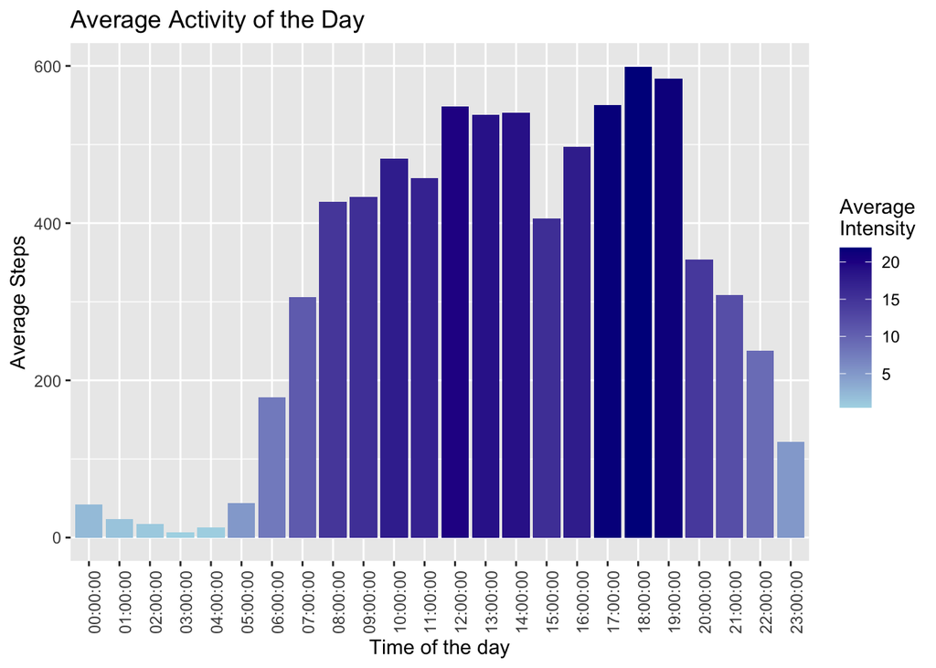

```r
# Most active time of the day
avg_hourly_activity <- hourly_all %>%
  select(Id, time, TotalIntensity, StepTotal) %>%
  group_by(time) %>%
  summarise(total_step_mean = mean(StepTotal),
            total_intensity_mean = mean(TotalIntensity))

ggplot(avg_hourly_activity, aes(x = time, y = total_step_mean, fill = total_intensity_mean)) +
  geom_col()+
  scale_fill_gradient(low = "light blue", high = "dark blue") +
  theme(axis.text.x = element_text(angle = 90)) +
  labs(x = 'Time of the day',
       y = 'Average Steps',
       title = 'Average Activity of the Day',
       fill = 'Average\nIntensity')
```

### 4-2. Users are sedentary during most of their active time

Next, we want to know how users spend their time when they are awake; that is, how active are the users during their active (awake) time, including sedentary time.

Here, we calculate % of each level of activities in their total active time.

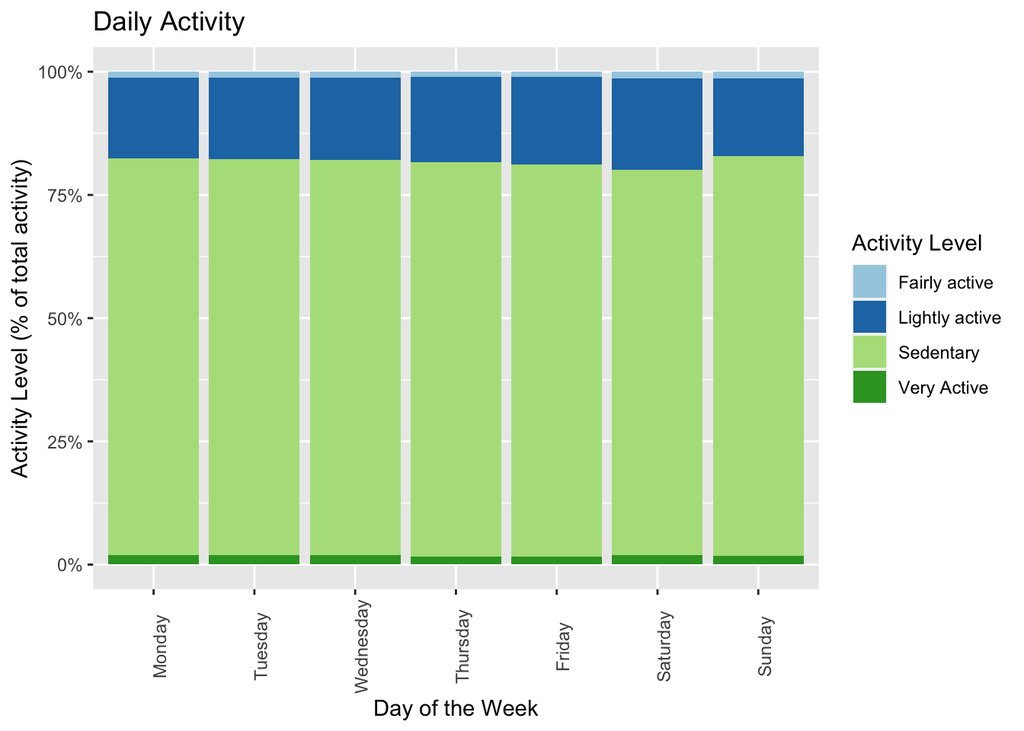

```r
# Most active day of the week
avg_daily_activity <- daily_all %>%
  mutate(total_activity = VeryActiveMinutes + FairlyActiveMinutes + LightlyActiveMinutes + SedentaryMinutes,
        pct_very_active = VeryActiveMinutes / total_activity * 100,
        pct_fairly_active = FairlyActiveMinutes / total_activity * 100,
        pct_lightly_active = LightlyActiveMinutes / total_activity * 100,
        pct_sedentary = SedentaryMinutes / total_activity * 100) %>%
  group_by(Weekday) %>%
  summarise(pct_very_active_mean = mean(pct_very_active),
            pct_fairly_active_mean = mean(pct_fairly_active),
            pct_lightly_active_mean = mean(pct_lightly_active),
            pct_sedentary_mean = mean(pct_sedentary),
            total_step_mean = mean(TotalSteps),
            total_dist_mean = mean(TotalDistance),
            very_active_mean = mean(VeryActiveMinutes),
            lightly_active_mean = mean(LightlyActiveMinutes),
            activity_mean = mean(total_activity - SedentaryMinutes),
            calories_mean = mean(Calories))

# Transform data to long form
activity <- avg_daily_activity %>%
  select(Weekday, pct_very_active_mean, pct_fairly_active_mean, pct_lightly_active_mean, pct_sedentary_mean) %>%
  pivot_longer(c("pct_very_active_mean", "pct_fairly_active_mean", "pct_lightly_active_mean", "pct_sedentary_mean"),
               names_to = 'activity_level', values_to = 'percent_activity')

ggplot(activity,
       aes(x = Weekday, y = percent_activity, fill = activity_level)) +
  geom_bar(position = "fill",stat = "identity") +
  scale_y_continuous(labels = scales::percent_format()) +
  scale_fill_brewer(palette = "Paired",
                    labels = c('Fairly active', 'Lightly active', 'Sedentary', 'Very Active')) +
  theme(axis.text.x = element_text(angle = 90)) +
  labs(title = 'Daily Activity',
       x = 'Day of the Week',
       y = 'Activity Level (% of total activity)',
       fill = 'Activity Level')
```

### 4-3. Average steps & calories burned

Next, we want to see if users reach their daily steps and calories burned.

According to CDC, average American takes 3,000 to 4,000 steps per day and they recommend 10,000 per day for general health. And thus, many pedometers track to see if users reach 10,000 steps per day.

Medical News Today: [How many steps should people take per day?](https://www.medicalnewstoday.com/articles/how-many-steps-should-you-take-a-day)

Mayo Clinics: [10,000 steps a day: Too low? Too high?](https://www.mayoclinic.org/healthy-lifestyle/fitness/in-depth/10000-steps/art-20317391)

Studies consider 10,000 steps per day active and is a good baseline. Let's look at how many steps the users have and if they reach 10,000 steps per day.

Reference: [How Many Steps Should You Aim for Each Day?](https://www.verywellfit.com/how-many-steps-per-day-are-enough-3432827)

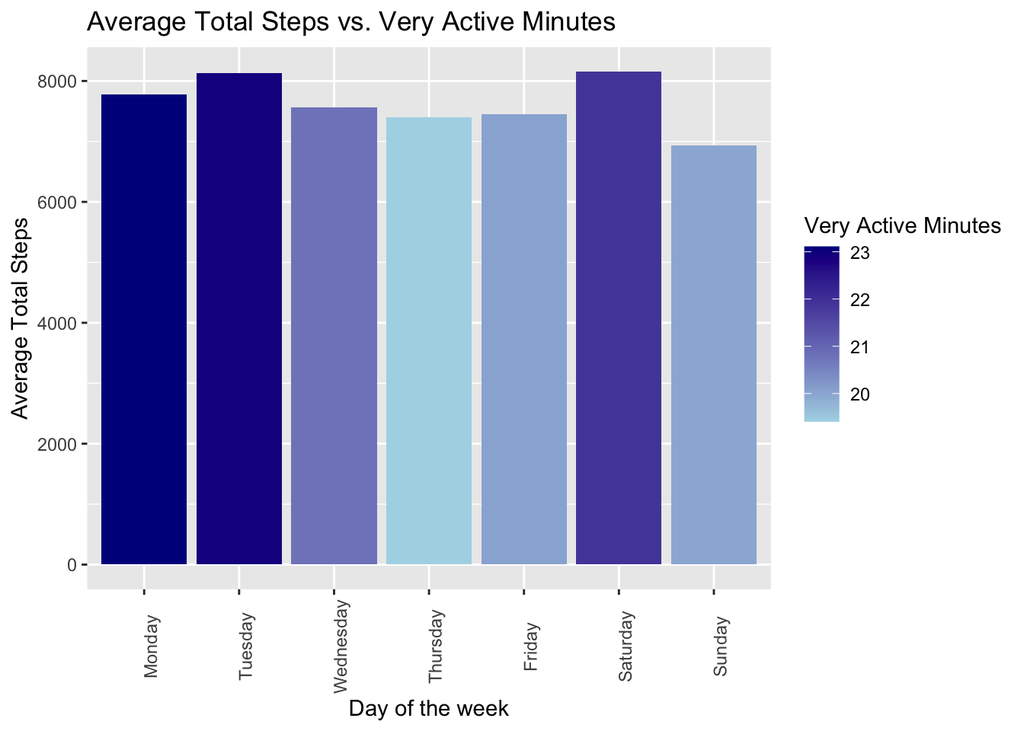

```r
# Steps vs. Very Active minutes
ggplot(avg_daily_activity, aes(x = Weekday, y = total_step_mean, fill = very_active_mean)) +
  geom_col()+
  scale_fill_gradient(low = "light blue", high = "dark blue") +
  theme(axis.text.x = element_text(angle = 90)) +
  labs(x = 'Day of the week',
       y = 'Average Total Steps',
       title = 'Average Total Steps vs. Very Active Minutes',
       fill = 'Very Active Minutes')
```

Thses Fitnit users have higher daily steps than genernal Americans but still lower than the recommended 10,000 steps and less than 30 minutes per day. They may need to increase additional 30 min of activities to reach the goal.

Next, we look at daily calories burned. Adults typically burn about 2,000 to 2,500 calories per days. If we want to maintain current weight, number of calories consumed need to be the same as we burn each day. If we want to lose weight, then we need to burn more calories than we consumed.

Reference: [How Many Calories Should I Burn in a Day?](https://www.nike.com/a/how-many-calories-should-you-burn-daily)

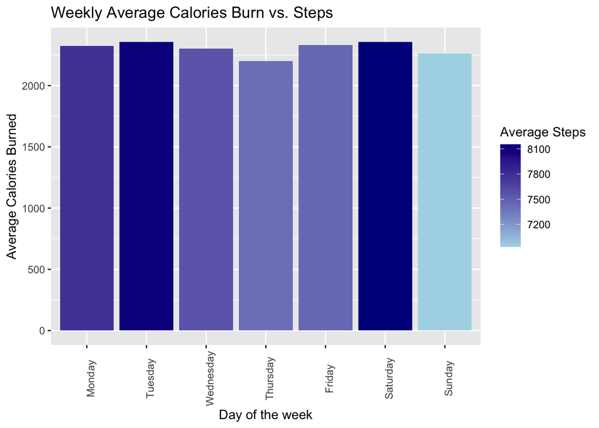

```r
# Calories vs. Steps
ggplot(avg_daily_activity, aes(x = Weekday, y = calories_mean, fill = total_step_mean)) +
  geom_col()+
  scale_fill_gradient(low = "light blue", high = "dark blue") +
  theme(axis.text.x = element_text(angle = 90)) +
  labs(x = 'Day of the week',
       y = 'Average Calories Burned',
       title = 'Weekly Average Calories Burn vs. Steps',
       fill = 'Average Steps')
```

We can see that daily calories burned are around 2000 to 2500 calories with 7,000 to 8,200 steps per day, which means that users can only intake this much calories to maintain their weight. This may be difficult with American style food.

### 4-4. Sleep Qaultiy

How about their sleep? We want to know how long do they spend time in bed and how long they actually asleep during their time in bed.

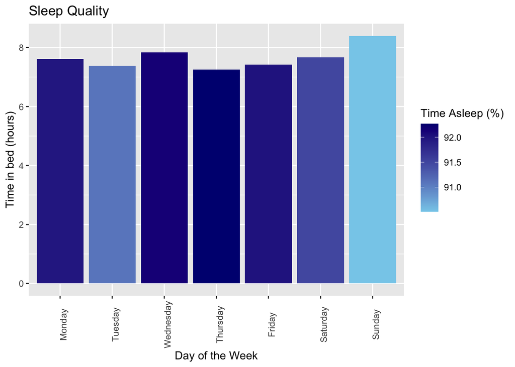

```r
sleep_time <- daily_all %>%
  drop_na() %>%
  mutate(time_in_bed = TotalTimeInBed / 60,
         time_asleep = TotalMinutesAsleep / 60,
         percent_asleep = TotalMinutesAsleep / TotalTimeInBed * 100) %>%
  select(Id, ActivityDate, Weekday, time_in_bed, time_asleep, percent_asleep)

avg_sleep_time <- sleep_time %>%
  group_by(Weekday) %>%
  summarise(avg_total_in_bed = mean(time_in_bed),
            avg_total_asleep = mean(time_asleep),
            avg_per_asleep = mean(percent_asleep))

ggplot(avg_sleep_time, aes(x = Weekday, y = avg_total_in_bed, fill = avg_per_asleep)) +
  geom_col()+
  scale_fill_gradient(low = "skyblue", high = "navy blue") +
  theme(axis.text.x = element_text(angle =90)) +
  labs(title = 'Sleep Quality',
       x = 'Day of the Week',
       y = 'Time in bed (hours)',
       fill = 'Time Asleep (%)')
```

## Summary

From the above data, we know that:

1. Users likely workout between 5 - 7 pm each day
2. During the weekdays, 80% of the time, users are sedentary.
3. Averge steps are around 7000 to 82000 steps daily, which are less than the recommended 10,000 steps; active time is also less than the recommended 30 minutes.
4. Calories burned are around 2000 to 2500 each day.
5. Users generally sleep less than 8 hour per day.